# Replication of the Online Visual Crowding Experiment Using the Virtual Chinrest by Li et al.(2020, Scientific Reports)

#### Figure 7e:

##### Within-subject viewing distance ICC and pairwise correlation.

Original 7e (Li e al., 2020):

```r
# reproduce original 7e
#transfer the df from long to wide
original_viewing_distance_wide <- spread(original_viewing_distance_by_session, session, viewDistance)
names(original_viewing_distance_wide)[2:4] <- c('s1','s2','s3')

#calculate original ICC
ICC(original_viewing_distance_wide[,c(2,3,4)],missing=TRUE,alpha=.05)
```

```
## Call: ICC(x = original_viewing_distance_wide[, c(2, 3, 4)], missing = TRUE,
##     alpha = 0.05)
##
## Intraclass correlation coefficients
##                          type  ICC   F df1  df2        p lower bound
## Single_raters_absolute   ICC1 0.71 8.4 804 1610 2.2e-282        0.69
## Single_random_raters     ICC2 0.71 8.4 804 1608 2.2e-282        0.69
## Single_fixed_raters      ICC3 0.71 8.4 804 1608 2.2e-282        0.69
## Average_raters_absolute ICC1k 0.88 8.4 804 1610 2.2e-282        0.87
## Average_random_raters   ICC2k 0.88 8.4 804 1608 2.2e-282        0.87
## Average_fixed_raters    ICC3k 0.88 8.4 804 1608 2.2e-282        0.87
##                         upper bound
## Single_raters_absolute         0.73
## Single_random_raters           0.73
## Single_fixed_raters            0.73
## Average_raters_absolute        0.89
## Average_random_raters          0.89
## Average_fixed_raters           0.89
##
##  Number of subjects = 805     Number of Judges =  3
## See the help file for a discussion of the other 4 McGraw and Wong estimates,
```

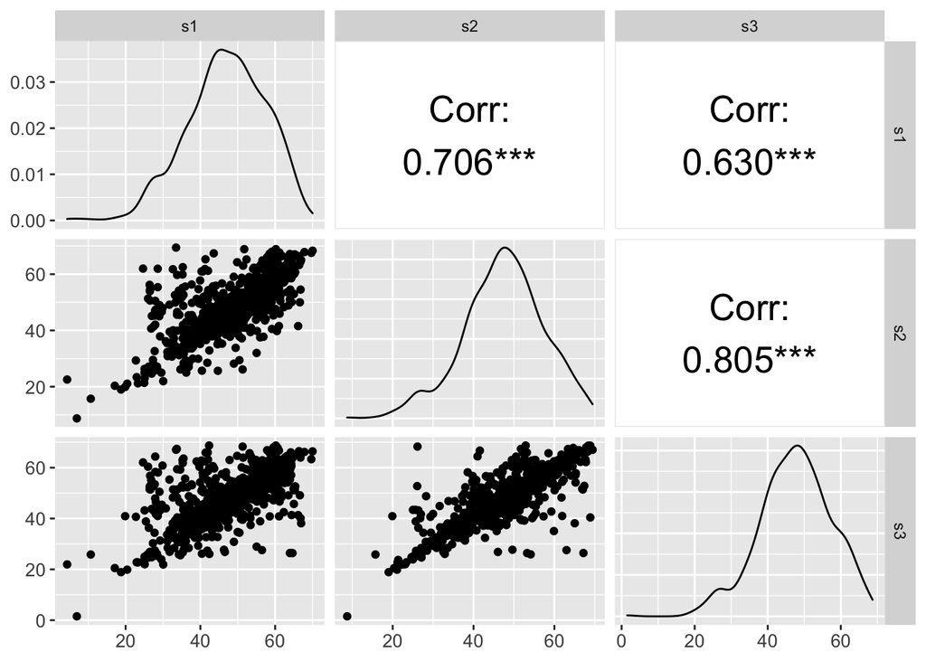

```r
#draw Fig. 7e
original_plot_7e <- ggpairs(original_viewing_distance_wide, columns = 2:4, upper = list(continuous = wrap("cor", size=7, color='black'))) +
  theme(axis.text = element_text(size = 10))
original_plot_7e
```

Replication 7e (Ma, 2021):

```r
#transfer the df from long to wide
viewing_distance_wide <- spread(viewing_distance_reshape_df, time, viewDistance)
names(viewing_distance_wide)[2:4] <- c('s1','s2','s3')

#calculate ICC
ICC(viewing_distance_wide[,c(2,3,4)],missing=TRUE,alpha=.05)
```

```
## Call: ICC(x = viewing_distance_wide[, c(2, 3, 4)], missing = TRUE,
##     alpha = 0.05)
##
## Intraclass correlation coefficients
##                          type  ICC F df1 df2       p lower bound upper bound
## Single_raters_absolute   ICC1 0.57 5  36  74 2.3e-09        0.42        0.71
## Single_random_raters     ICC2 0.57 5  36  72 2.8e-09        0.42        0.71
## Single_fixed_raters      ICC3 0.57 5  36  72 2.8e-09        0.42        0.71
## Average_raters_absolute ICC1k 0.80 5  36  74 2.3e-09        0.69        0.88
## Average_random_raters   ICC2k 0.80 5  36  72 2.8e-09        0.69        0.88
## Average_fixed_raters    ICC3k 0.80 5  36  72 2.8e-09        0.69        0.88
##
##  Number of subjects = 37     Number of Judges =  3
## See the help file for a discussion of the other 4 McGraw and Wong estimates,
```

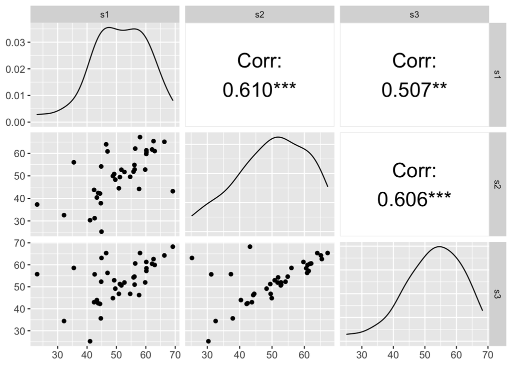

```r
#draw Fig. 7e
replication_plot_7e <- ggpairs(viewing_distance_wide, columns = 2:4, upper = list(continuous = wrap("cor", size=7, color='black'))) +
  theme(axis.text = element_text(size = 10))

replication_plot_7e
```

### Exploratory analyses

The original study has a broader age range (7-71), while my study only recruited young adults (18-30). The original study and their references showed older adults exhibited a larger crowding effect, particularly at greater eccentricity (6 deg). The following analyses will plot and compare 1) the distribution of age and 2) the the impact of age on the visual crowding effect between the original and my replication study.

#### Distribution of age

```r
original_visual_crowding_age <- aggregate(age~uuid, data = original_visual_crowding_no_dyslexia, mean)

#histgram of participant accuracy
original_plot_age <- ggplot(original_visual_crowding_age, aes(x=age)) + geom_histogram(aes(y=..density..), binwidth = 1.0, alpha=.8) +
  geom_vline(aes(xintercept=mean(age)), color="red", size=1) +
  geom_density(alpha=.2, fill="grey") +
  scale_x_continuous(breaks = scales::pretty_breaks(n = 5)) +
  labs(title="", x="age", y="Density") +
  theme_grey(base_size = 15)

#summary: mean, min, max
summary(original_visual_crowding_age$age)
```

| Min. | 1st Qu. | Median | Mean | 3rd Qu. | Max. |
| --- | --- | --- | --- | --- | --- |
| 7 | 19 | 22 | 27.28376 | 33 | 71 |

```r
visual_crowding_age <- aggregate(age~participantID, data = visual_crowding, mean)

#histgram of participant accuracy
replication_plot_age <- ggplot(visual_crowding_age, aes(x=age)) + geom_histogram(aes(y=..density..), binwidth = 1.0, alpha=.8) +
  geom_vline(aes(xintercept=mean(age)), color="red", size=1) +
  geom_density(alpha=.2, fill="grey") +
  scale_x_continuous(breaks = scales::pretty_breaks(n = 5)) +
  labs(title="", x="age", y="Density") +
  theme_grey(base_size = 15)

#summary: mean, min, max
summary(visual_crowding_age$age)
```

| Min. | 1st Qu. | Median | Mean | 3rd Qu. | Max. |
| --- | --- | --- | --- | --- | --- |
| 19 | 21 | 22 | 22.62162 | 25 | 30 |

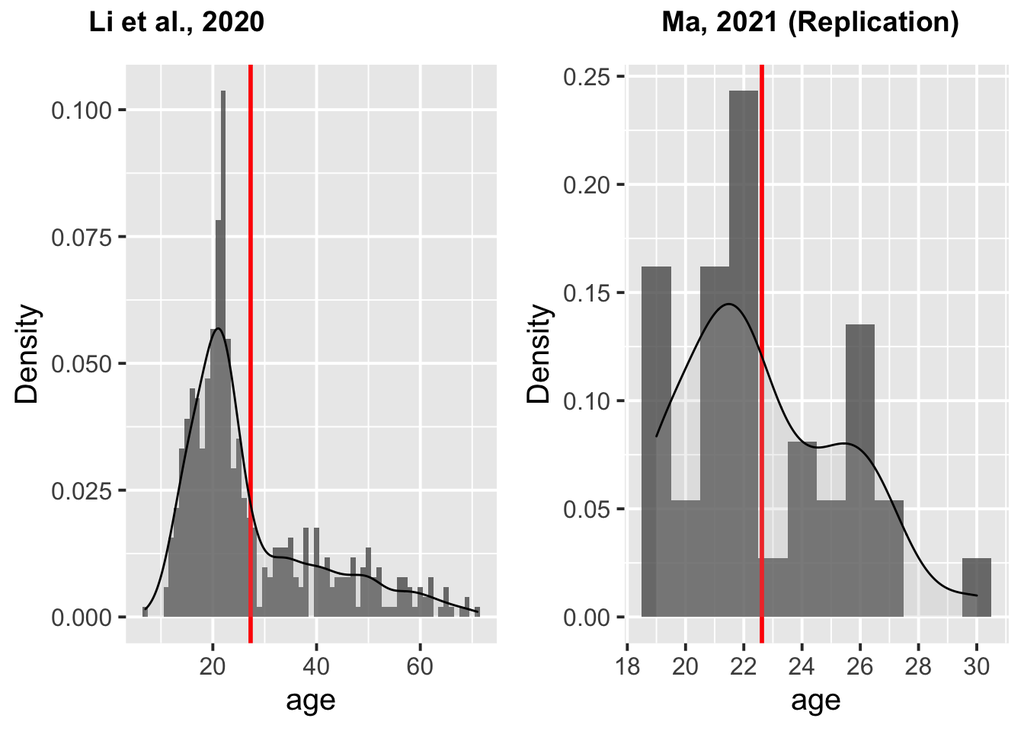

```r
# compare age distribution
plot_grid(original_plot_age, replication_plot_age, labels = c('Li et al., 2020', 'Ma, 2021 (Replication)'))
```

#### Relationship between age and visual crowding effect

##### Original (Li et al., 2020)

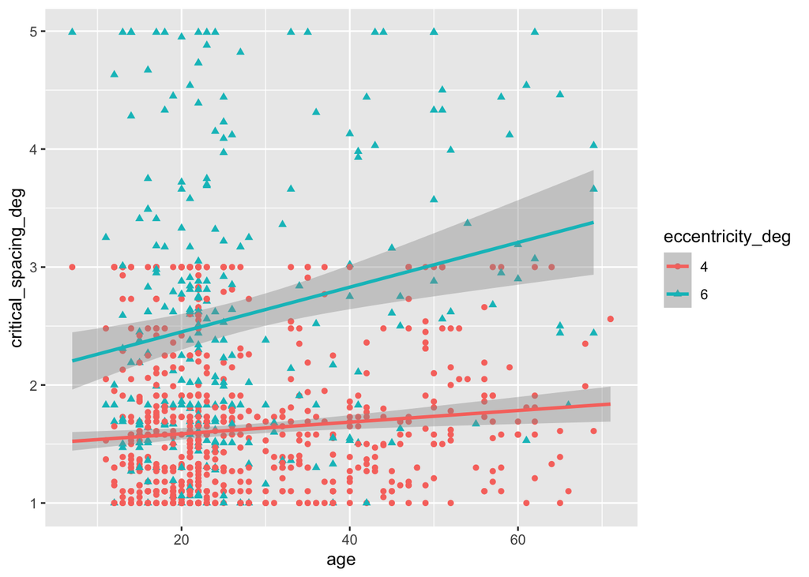

```r
original_visual_crowding_no_dyslexia <- original_visual_crowding_no_dyslexia %>%
  convert(chr(eccentricity_deg))

ggplot(original_visual_crowding_no_dyslexia, aes(x=age, y=critical_spacing_deg, color=eccentricity_deg,shape = eccentricity_deg)) +
  geom_point() +
  geom_smooth(method=lm)
```

##### Replication (Ma, 2021)

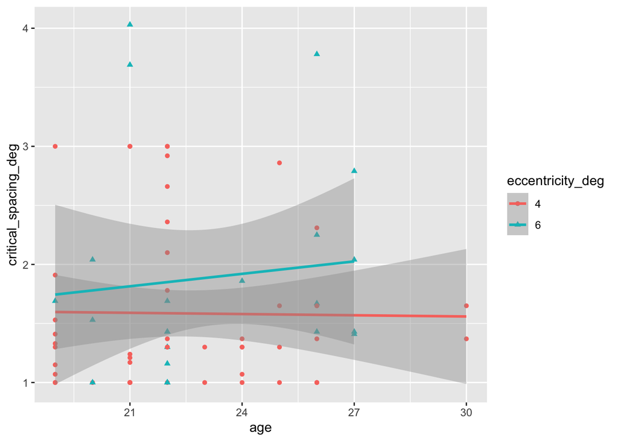

```r
convert_visual_crowding <- visual_crowding %>%
  convert(chr(eccentricity_deg))

ggplot(convert_visual_crowding, aes(x=age, y=critical_spacing_deg, color=eccentricity_deg,shape = eccentricity_deg)) +
  geom_point() +
  geom_smooth(method=lm)
```